# Reds Notebook

Harrison Cradduck, Joey Endres, Will Paz

2025-02-16

## Introduction

> This notebook is designed to detail the processes in which we wrangled the data given to us in Kaggle, we fitted and selected various models, we validated said models, and we chose our final model for submission. We were tasked with the question of predicting a Cincinnati Reds players’ total playing time in the 2024 season using play-by-play data from 2021, 2022, and 2023. The sections below aim to display our thoughts and ideas on how we should go about cleaning the data, organizing the data, fitting an appropriate and insightful model, and implementing it for our final submission.

## Data Wrangling

> Our initial approach to the data was organizing both the Savant and Lahman data to be specific to batters and pitchers separately. This allowed us to create two comprehensive data frames of every variable we deemed “possibly relevant” to predicting a batter or pitcher’s playing time (playing time being measured in plate appearances for batters and at-bats faced for pitchers). Creating these lists involved pivoting variables like type of pitch, play event, and how the ball was hit into their separate categorical values to be treated independently within a regression model. Then depending on the type of variable, we created either averages (ex. launch speed, hit distance) or totals (ex. singles, field outs) for a player by at-bat, then by game, then by season, and ultimately in total; a weighted average was implemented based on total plate appearances or batters faced in a game and season.

> Once these lists were complete, we combined them into one data frame for all players, making the distinction between shared variables (ex. total singles hit batting vs. total singles allowed pitching) for players that played both sides of the ball at one point or another. One thing that was taken into consideration for ensuring the best data was being used for predictions was removing pitchers that batted at some point in the 2021-2023 seasons other than Shohei Ohtani, as pitchers very rarely bat after the conclusion of the 2021 season. We want our data to be fitted to the same constraints imposed on the 2024 season.

## Regression Modeling Selection & Validation

> When approaching this question, we decided to go with a traditional statistical approach to model building. Our first step was to split our data into a training and testing split, where we chose an 80/20 split. Then using our training data, we started with fitting a full regression model to create a baseline model. Obviously, the entire model predicts the data well, but as with most statistical models, we want to find the simplest model that performs well by satisfying basic statistical modeling practices. We began to pick the best model by using all combinations of forward, backward, and stepwise selection by AIC and BIC comparison and comparing their quantitative results to one another. We found that the backward variable selection using AIC was by far the best choice using various metrics.

> Next, we decided to remove insignificant variables of our new model by applying the stepwise selection based on BIC on our backward selection AIC model with k-fold validation to ensure we found the simplest and significant model. After that, we wanted to remove multicollinearity in our model since the multicollinearity assumption in our model could not be accepted, so we checked the VIF of each variable and found a reasonable threshold to remove variables. Lastly, we removed any contextual outliers that would not accurately represent the prediction of playing time in a vacuum of baseball. We landed on a model that consists of 10 variables, for which the model can reasonably accept the normality, multicollinearity, constant variance, and independence assumptions.

> What makes this model different than the others is the fact that we have 10 variables in our model, all of which allow for no assumption violations and do not constitute another measure/variation of playing time. The way we think of it, if we have two models side to side with one that performs slightly better and one that consists of fewer predictors and less contextually similar variables, we would choose the latter. The fact that we could have predicted play time using something similar to average AB/Game or a contextually similar predictor to the response and didn’t, is what we believe makes our model unique and meaningful when predicting play time in a vacuum. Our objective was to predict playing time without using any measure of playing time as a predictor, and our model reflects just that.

## Findings

> Using the model selection process above, we isolated 10 variables that have both meaningful and contextual significance: total strikeouts batted, total walks pitched, total singles pitched, total singles batted, average iso value, total walks batted, average delta run expectancy pitched, total batters faced as a relieving pitcher, average pitches thrown in an outing, and average times facing a pitcher in a game. Each predictor shows a positive relationship with playing time besides the average delta run expectancy pitched, which logically makes sense. In addition to only having 10 predictor variables in our model, the adjusted R^2 value is roughly 0.88, indicating much of the variability in playing time is explained by our variables.

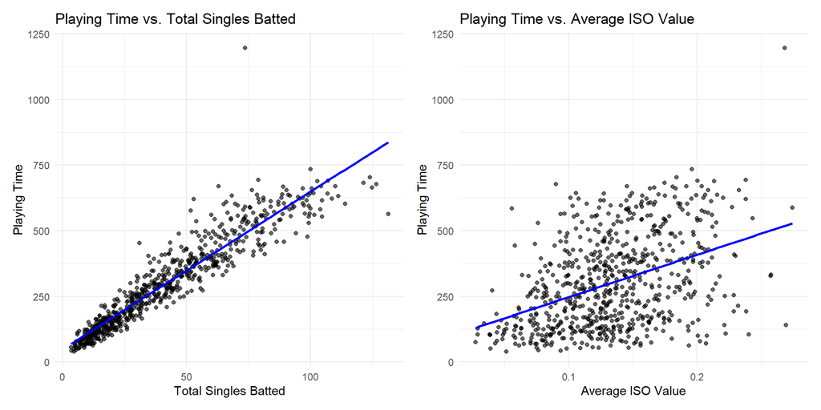

> The next set of scatterplots demonstrates the relationships in playing time with total walks batted and total strikeouts batted. Both predictors have strong linear relationships with playing time, though it can be seen the effects of total walks and strikeouts on playing time as they become very large seem to diminish (a logarithmic-like pattern).

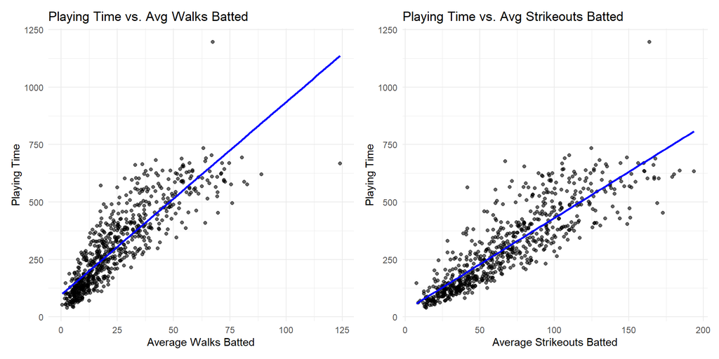

> Lastly, we created a graph reflecting how predictive the average amount of pitches a pitcher throws in a game is of a pitcher’s average playing time, separated by starter and reliever. Interestingly, there seems to be little association between a reliever’s pitch totals and their playing time, though logically this would make sense as their totals relate more to the inning they begin in the outing versus how quickly they can get a batter out. On top of this, the ability for a pitcher to up their average pitch count looks to have a quadratic relationship with their playing time. This suggests that a pitcher’s arm endurance is crucial to seeing them excel as a starter, and working to increase their stamina could directly lead to an exponential increase in playing time.

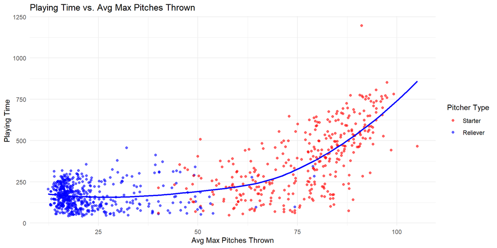

## Discussion & Limitations

> We evaluated our models throughout the selection process by RMSE in addition to the usual qualitative and quantitative metrics, and upon submission, we realized our numbers weren’t as straightforward due to the submission being calculated on 10% of the test data. This led us to assess where we may have gone wrong but nothing apparent came to mind. Our hope is that testing on the remaining 90% for the final submission will work in our favor, but ultimately we are happy to have been able to participate in this opportunity to showcase our skills and advise the Reds analytics team. Additional methods we did not flesh out were using each year to predict the next (ex. 2022 predicting 2023), attempting to account for recency bias in some way, or manipulating the data to add additional variables and metrics with possible predictive power (ex. ERA, WAR).

## Appendix

> Our code can be accessed in this GitHub repository: https://github.com/WillPaz16/redsHackathon2025.git.